# Autocorrelation case

## About autocorrelation

Autocorrelation is the correlation of a signal with a delayed copy of itself as a function of delay. Informally, it is the similarity between observations as a function of the time lag between them.

The analysis of autocorrelation is a mathematical tool for finding repeating patterns, such as the presence of a periodic signal obscured by noise, or identifying the missing fundamental frequency in a signal implied by its harmonic frequencies. It is often used in signal processing for analyzing functions or series of values, such as time domain signals.

## Example

To see how autocorrelation helps detecting the repeated patterns at practice, we create the below time-series data. We can see a obvious pattern `c(0, 0.5, 1, 0, 2, 0, 3)` repeating 10 times.

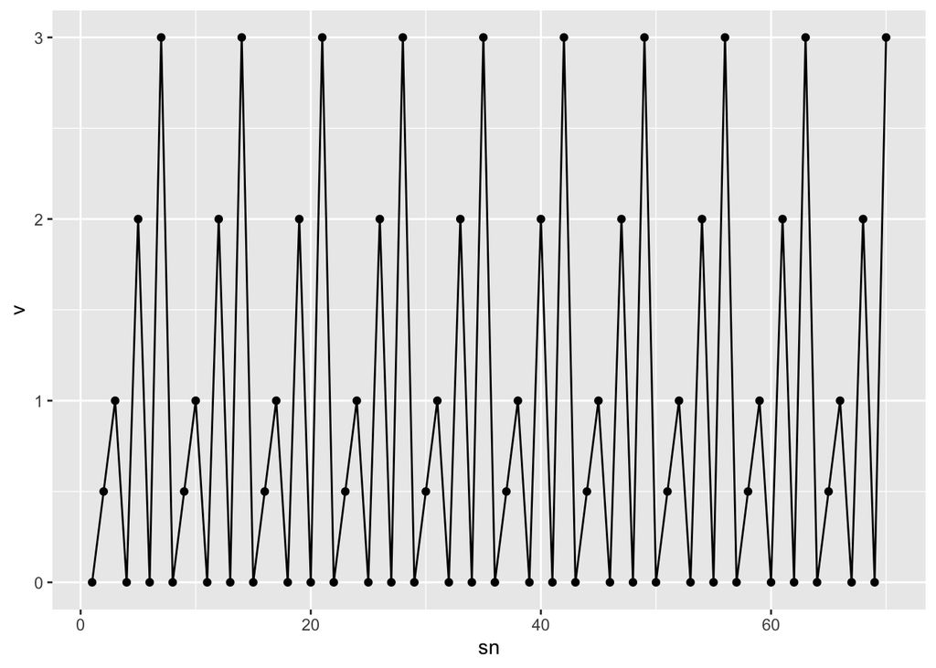

```r
library(ggplot2)
data <- data.frame(v=rep(c(0, 0.5, 1, 0, 2, 0, 3), times=10))
data$sn <- as.numeric(row.names(data))
ggplot(data, aes(x=sn, y=v)) + geom_line() + geom_point()
```

By applying `acf()`, we can see it calculates the correlation rate for different lags. Among them, the lag-7 has the highest correlation rate (0.900). It shows that `acf()` can indeed successfully detect the repeated pattern.

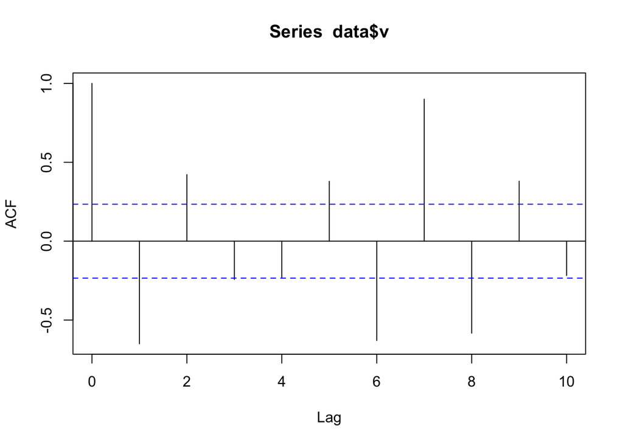

```r
acf(data$v, lag=10, pl=TRUE)
```

```r
acf(data$v, lag=10, pl=FALSE)
```

```
##
## Autocorrelations of series 'data$v', by lag
##
##      0      1      2      3      4      5      6      7      8      9     10
##  1.000 -0.650  0.422 -0.242 -0.229  0.379 -0.630  0.900 -0.583  0.380 -0.218
```